# Elements of AI Practicum 2.2

Regression Problems

When we talk about regression modeling in the context of FIFA data, we’re referring to statistical techniques used to understand and predict various outcomes based on player attributes. For example, we might use regression models to predict a player’s market value, performance, or potential based on their age, overall rating, skill moves, and other attributes. Sometimes, attributes act independently and are modeled as such. Other times, attributes interact with each other, and a faithful representation of their combined impact requires an interaction term. A wise data scientist must therefore choose carefully which attributes to include in a model and whether to keep the model simple or make it more complex. This is, after all, what you will practice today.

### Objective(s)

- Model relationship between predictors and dependent variables using linear or polynomial regression. Understand difference between attribute co-linearity and interaction. Understand difference between simple and multiple regression models.
- Understand the difference between predicting a dependent variable from on one or more attributes and estimating the contribution of each attribute to the prediction.
- Interpret the model parameters and statistics.

### Hypothesis Formulation

We hypothesize that a striker’s performance on the field, whether measured by their `overall` score or monetary value (`value_eur`), depends on their technical skills, attacking and defending abilities, raw power, mentality, and stamina. But which ones to take and how to assess their relationship?

### Data

To validate or refute hypothesis, you will delve into the football player records from the 2022 season of the FIFA dataset. The relevant file, `players_22.csv`, is accessible on Kaggle[^1] and is also included as a local copy with your study materials for your convenience.

### Selecting Attributes

The FIFA22 dataset includes numerous attributes that are highly relevant for hypothesis testing. However, without thorough analysis, it’s challenging to determine which attributes, or combinations thereof, are optimal for model building. In such cases, you can either make random selections or choose one, two, or three attributes based on your football knowledge. If you’re uncertain about which attributes to select, consider some of these examples that might influence a player’s offensive performance.

**Speed and Dribbling:** The effect of a player’s speed on their ability to get past defenders might depend on his dribbling skills. A fast player with excellent dribbling skills can maneuver around defenders more effectively than a fast player with poor dribbling skills.

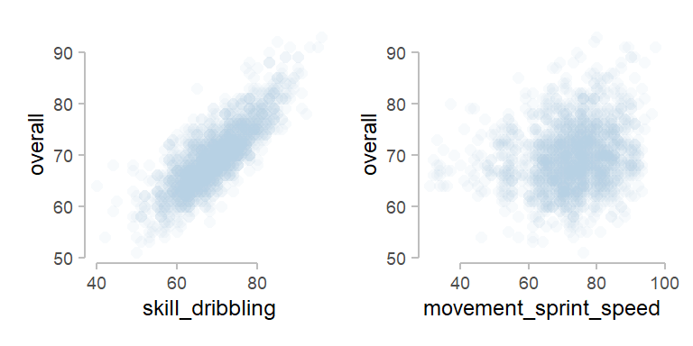

**Passing and Vision:** The effect of player’s passing accuracy on their ability to create goal-scoring opportunities might depend on their vision. A player with high passing accuracy and excellent vision can spot and execute difficult passes that lead to goals.

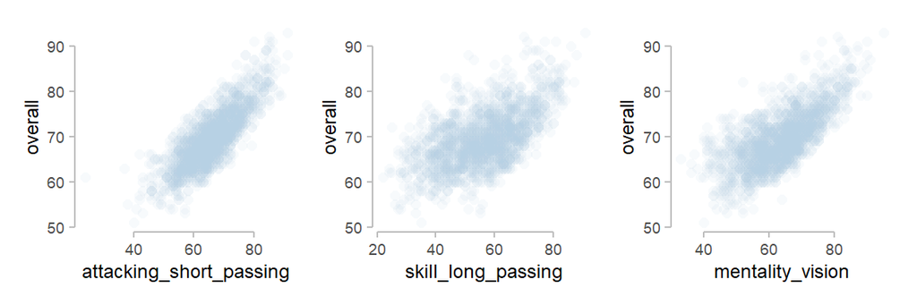

**Strengths and Heading Accuracy:** The effect of a player’s strength on their ability to win areal duels might depend on their heading accuracy. A strong player with good heading accuracy can dominate in the air and score goals from crosses and set-pieces[^2].

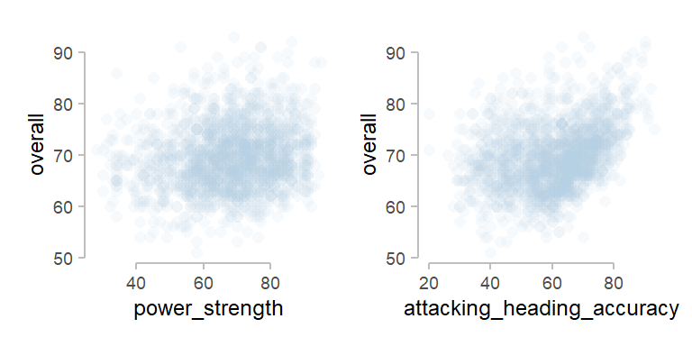

### Model Building

Formulate a hypothesis and create one or more multiple regression models to capture the relationship between the dependent variable and the selected attribute(s). Thoughtfully consider which attributes to include and whether interactions are relevant.

Next, evaluate model performance parameters and determine the optimal degree of the polynomial fit with cross validation. Assess whether the relationship is best modeled with multiple predictors, with or without interaction terms. Conduct a power analysis to ensure your sample size is sufficient to detect the effect given the number of model parameters.

### Make Sure To

- start by performing exploratory data analysis to select the best predictors for your hypothesis. Use summary statistics, visualizations, and correlation matrices to understand the relationships between variables.
- use one multiple regression model instead of multiple single ones to understand how predictors work together and impact the target variable.
- use polynomial fitting instead of simple linear regression in cases where relationships are nonlinear. Determine the correct polynomial degree to prevent overfitting by using techniques like cross-validation.
- interpret the model parameters to identify predictors that significantly affect the target variable. Focus on the most impactful predictors and keep the model simple for better understandability.
- create residual scatter plots and examine them for signs of homoscedasticity. Be sure to analyze the model error and interpret performance parameters. Pay particular attention to attribute selection, outlier identification, and parameters that indicate the linearity of the relationship between the predictors and the dependent variable.

### What Do I Need To Know Before Starting?

A solid theoretical foundation in regression model building is essential. While most plots and data manipulation tasks can be performed using the base R plotting system and syntax, consider doing **Tutorials 3.1** through **3.4** and Tutorials **5.1** and **5.2** before attempting this exercise.

### Footnotes

[^1]: www.kaggle.com/datasets/stefanoleone992/fifa-22-complete-player-dataset
[^2]: In football, a set-piece refers to a situation where the game is restarted with a standardized method after the ball has gone out of play or a foul has been committed. Common set-pieces include free kicks, corner kicks, and throw-ins. These moments are often strategically important, as they provide teams with an opportunity to create scoring chances from a controlled position. Set-pieces can be meticulously planned and practiced, with players knowing their specific roles and movements to maximize the chance of scoring a goal.